**студент гр. РИ-450004 Захаров Вячеслав**

# Лабораторная работа 1

Проверка следующих навыков: Манипулирование объектами данных; использование встроенных функций; построение простейших графиков; простейшие статистические концепции.

## Требования к оформлению

- Оформить решение в R Markdown.
- Сохранить файл в свой репозиторий.
- Выгрузить R Markdown в HTML, назвать своим именем и отправить по почте (если хочется сдать раньше или нужна помощь).

## Исходные данные

Экспоненциальное распределение определяется следующей функцией распределения:

```
F(x) = 1 - e^(-λ⋅x)
```

Функция `rexp` генерирует случайные переменные при помощи экспоненциального распределения `rexp(n=42, rate=5)` вернёт 42 экспоненциально-распределённых числа с параметром (λ) равным 5. Ели второй аргумент не указан, будет использовано значение 1 т.е. получим “стандартное экспоненциальное распределение”.

## Задание 1

1. Сгенерируйте 200 случайных значений из стандартного экспоненциального распределения и сохраните в вектор *exp.1*. Найдите среднее и стандартное отклонение из данных этого вектора.

```r
exp.1<-rexp(n=200)
mean_exp.1<-mean(exp.1)#среднее
sd_exp.1<-sd(exp.1)#стандартное отклонение
lambda1<-1
result<-data.frame("параметр распределения"=lambda1,"Среднее значение"=mean_exp.1,"Стандартное отклонение"=sd_exp.1)#отображение данных
result
```

```
##   параметр.распределения Среднее.значение Стандартное.отклонение
## 1                      1         0.927423              0.9010845
```

2. Повторите, использовав следующие значения параметра λ: 0.1, 0.5, 5, 10, и сохраните результаты в векторы: *exp.0.1*, *exp.0.5*, *exp.5*, *exp.10*.

```r
lambda_all<-c(0.1,0.5,5,10)
exp.01<-rexp(n=200,rate=lambda_all[1])
mean_exp.01<-mean(exp.01)#среднее
sd_exp.01<-sd(exp.01)#стандартное отклонение

exp.05<-rexp(n=200,rate=lambda_all[2])
mean_exp.05<-mean(exp.05)#среднее
sd_exp.05<-sd(exp.05)#стандартное отклонение

exp.5<-rexp(n=200,rate=lambda_all[3])
mean_exp.5<-mean(exp.5)#среднее
sd_exp.5<-sd(exp.5)#стандартное отклонение

exp.10<-rexp(n=200,rate=lambda_all[4])
mean_exp.10<-mean(exp.10)#среднее
sd_exp.10<-sd(exp.10)#стандартное отклонение

#сведем данные в общую таблицу
mean_exp_all<-c(mean_exp.01,mean_exp.05,mean_exp.5,mean_exp.10)
sd_exp_all<-c(sd_exp.01,sd_exp.05,sd_exp.5,sd_exp.10)

result<-data.frame("параметр распределения"=lambda_all,"Среднее значение"=mean_exp_all,"Стандартное отклонение"=sd_exp_all)#отображение данных
result
```

```
##   параметр.распределения Среднее.значение Стандартное.отклонение
## 1                    0.1      10.35373407             9.59889087
## 2                    0.5       1.98932093             1.75399175
## 3                    5.0       0.18386022             0.15878167
## 4                   10.0       0.08977621             0.08550698
```

3. Функция `plot()` общая функция для визуализации данных. Функция `hist()` принимает данные и раскладывает их по корзинам. Чтобы использовать эти функции нужно для начала передать им данные, которые хотим визуализировать.
4. Используйте функцию `hist()` для построения гистограммы полученного ранее стандартного распределения.

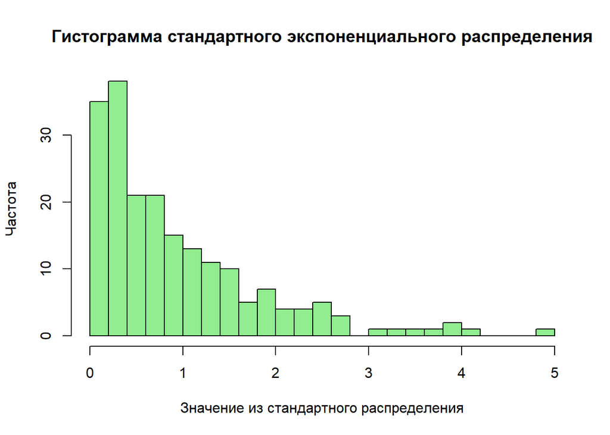

```r
hist(exp.1,breaks = 20,col = "lightgreen",
     xlab = "Значение из стандартного распределения",
     ylab="Частота",main = "Гистограмма стандартного экспоненциального распределения")
```

**Краткий вывод по гистограмме:** Из гистограммы видно, что распределение имеет экспоненциальный вид, частота появлений значений наибольшая при малых значениях величин.

2. Используйте функцию `plot()` с тем же самым вектором для построения графика значений в порядке следования.

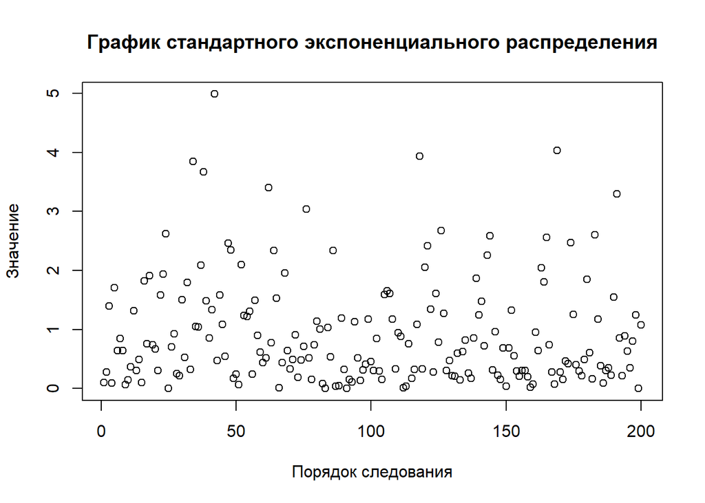

```r
plot(exp.1,xlab = "Порядок следования",ylab = "Значение",main = "График стандартного экспоненциального распределения")
```

**Краткий вывод по графику:** Из данного графика также видно, что большинство значений случайных переменных попало в область близкую к нулю. Так из графика видно, что основная часть значений попадает в область от 0 до 3 и лишь единичные значения выходят из этой области.

3. Используйте функцию `plot()` с любыми двумя полученными ранее векторами, чтобы получить диаграмму рассеяния ([scatterplot](https://www.mathsisfun.com/data/scatter-xy-plots.html)) этих векторов относительно друг друга.

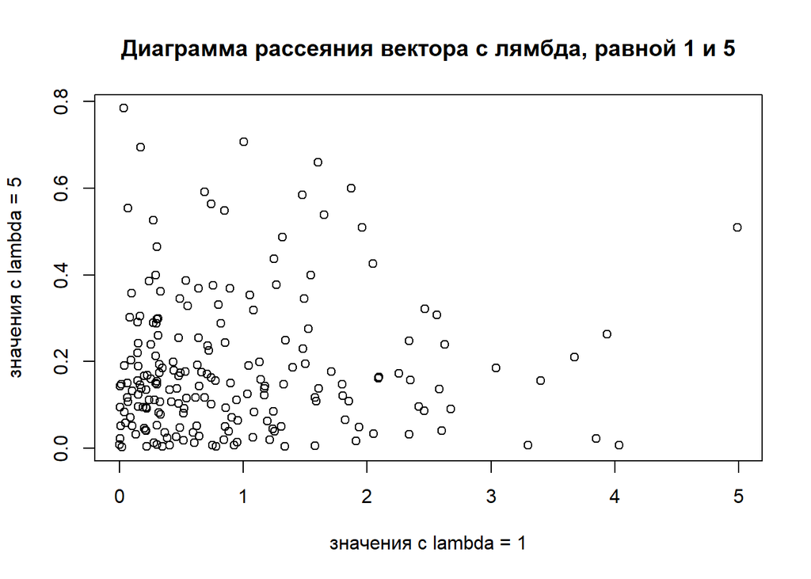

```r
plot(exp.1,exp.5,xlab = "значения с lambda = 1",ylab = "значения с lambda = 5",main = "Диаграмма рассеяния вектора с лямбда, равной 1 и 5")
```

**Краткий вывод по гистограмме:** Из данной гистограмме также видно, что при различных значениях параметра распределения (λ) основная часть значений попадает в область ближе к нулю. Также из данного графика видно, что при увеличении λ область, в которую попадают значения сужается, что показывает зависимость данного вида распределения.

4. Теперь сравним свойства всех наших векторов. Для начала создадим вектор, содержащий средние значения каждого из 5 полученных ранее распределений в порядке их создания. Полученный вектор сохраним в переменную *exp.means*.

```r
exp.means<-c(mean_exp.1,mean_exp.01,mean_exp.05,mean_exp.5,mean_exp.10)
```

Далее необходимо создать следующие диаграммы рассеяния: 1. Вектор с пятью средними относительно каждого из пяти векторов с различными значениями λ.

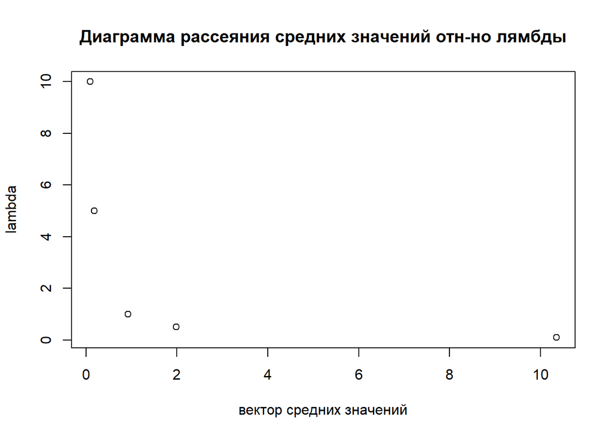

```r
lambda<-c(1,0.1,0.5,5,10)
plot(exp.means,lambda,xlab = "вектор средних значений",ylab = "lambda",main = "Диаграмма рассеяния средних значений отн-но лямбды")
```

**Краткий вывод по гистограмме:** Из данной диаграммы видно что при уменьшении значения параметра распределения λ среднее значения вектора увеличивается, что показывает особенности данного распределения.

2. Вектор с пятью стандартными отклонениями относительно каждого из пяти векторов с различными значениями λ.

[figure not shown]

```r
exp.sd<-c(sd_exp.1,sd_exp.01,sd_exp.05,sd_exp.5,sd_exp.10)
plot(exp.means,lambda,xlab = "вектор стандартных отклонений",ylab = "lambda",main = "Диаграмма рассеяния стандартных отклонений отн-но лямбды")
```

3. Вектор с пятью средними относительно вектора с пятью стандартными отклонениями.

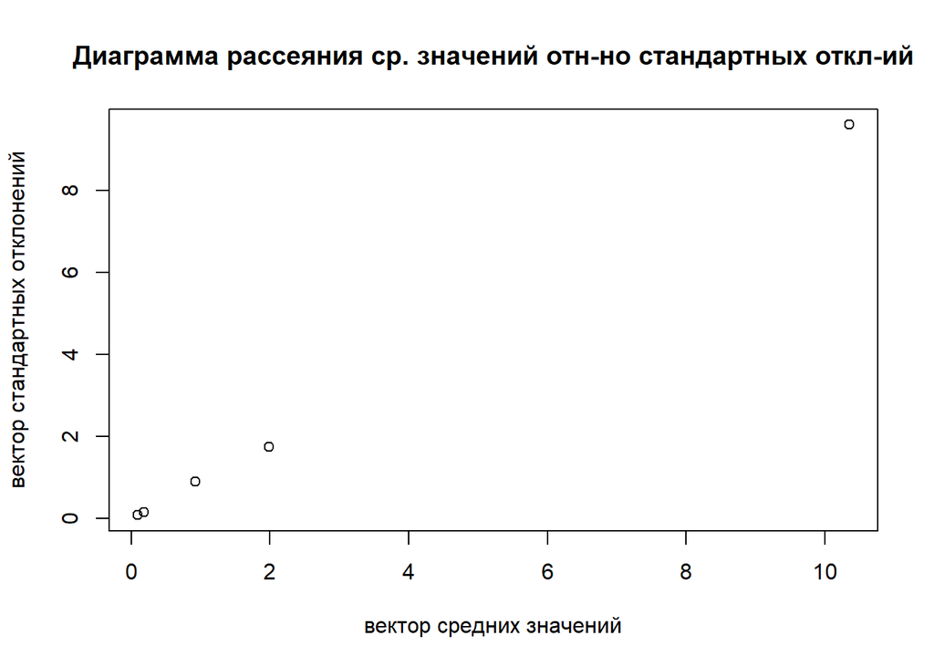

```r
plot(exp.means,exp.sd,xlab = "вектор средних значений",ylab = "вектор стандартных отклонений",main = "Диаграмма рассеяния ср. значений отн-но стандартных откл-ий")
```

**Краткий вывод по гистограмме:** Из данной диаграммы видно, что при увеличении средних значений при экспоненциальном распределении, вектор стандартных отклонений увеличивается практически линейно.

Для каждого графика, поясните увиденное.

## Задание 2

R достаточно производителен, чтобы вычислять относительно большие объёмы данных. * Для демонстрации сгенерируйте 1100000 (1 млн. 100 тысяч) чисел из стандартного экспоненциального распределения и сохраните их в вектор *huge.exp.1*. Получите среднее и стандартное отклонение.

```r
huge.exp.1<-rexp(1100000)
mean_huge.exp.1<-mean(huge.exp.1)
sd_huge.exp.1<-sd(huge.exp.1)
mean_huge.exp.1
```

```
## [1] 1.000715
```

```r
sd_huge.exp.1
```

```
## [1] 1.001511
```

- Получите гистограмму *huge.exp.1*. Она соответствует функции `1 - e:^(-x)`? Должна ли?

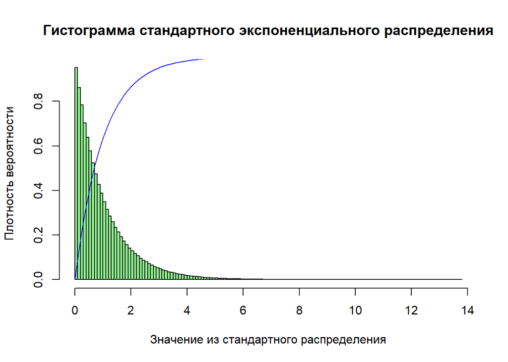

```r
hist(huge.exp.1,breaks = 100,freq = FALSE,col = "lightgreen",
     xlab = "Значение из стандартного распределения",
     ylab="Плотность вероятности",main = "Гистограмма стандартного экспоненциального распределения")
x<-0:1100000
f<-1-exp(-x)
curve(1-exp(-x),from = 0,to=8,add=TRUE,col="blue")
```

**Краткий вывод по гистограмме:** Данная гистограмма не соответствует функции `1 - e^(-x)`, но она и не должна ей соответствовать т.к. ф-ия F(x)=`1 - e^(-x)` является функцией распределения и показывает, зависимость значения случайной величины от значения ф-ии при данном распределении. А данная гистограмма отображает зависимость плотности вероятности появления случайной частоты, которая имеет следующую зависимость `f(x)=e^(-x)`.

- Получите среднее всех чисел из *huge.exp.1* строго больших 1. Для проверки выборки может потребоваться новый вектор.

```r
more.one<-huge.exp.1[huge.exp.1>1]
mean(more.one)
```

```
## [1] 2.003068
```

- Получите матрицу *huge.exp.1.mat*, содержащую 1100 строк и 1000 колонок. Постройте гистограмму, использовав полученную матрицу. Что можно сказать о полученных данных?

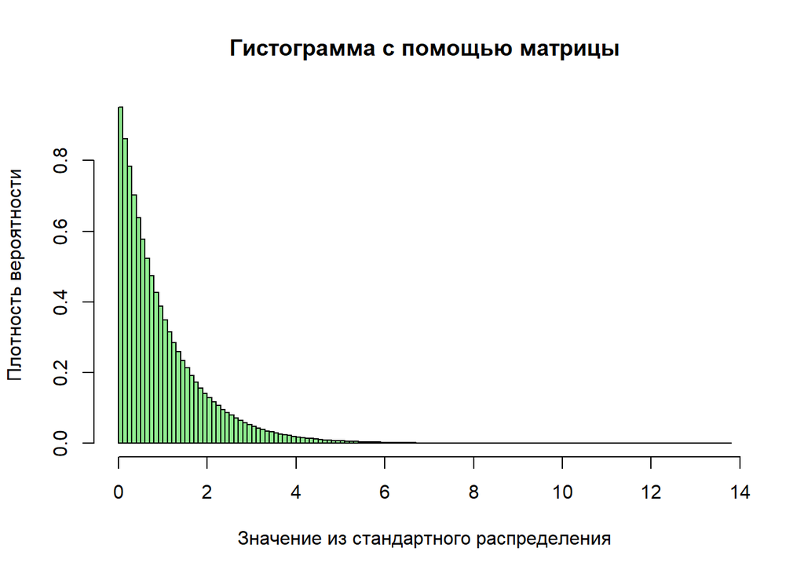

```r
huge.exp.1.mat<-matrix(data=huge.exp.1,nrow=1100,ncol=1000)
hist(huge.exp.1.mat,breaks = 100,freq = FALSE,col = "lightgreen",
     xlab = "Значение из стандартного распределения",
     ylab="Плотность вероятности",main = "Гистограмма с помощью матрицы")
```

**Краткий вывод по гистограмме:** Данная гистограмма получилась индентичная предыдущей, т.к. значения вектора и матрицы совпадают.

- Рассчитайте среднее 137-й колонки из *huge.exp.1.mat*.

```r
mean_huge.exp.1.mat<-mean(huge.exp.1.mat[,137])
mean_huge.exp.1.mat
```

```
## [1] 0.9749843
```

- Найдите среднее всех 1000 колонок и сохраните их в вектор. Отобразите диаграмму средних зннчений колонок. Объясните почему форма диаграммы отличается от виденных ранее.

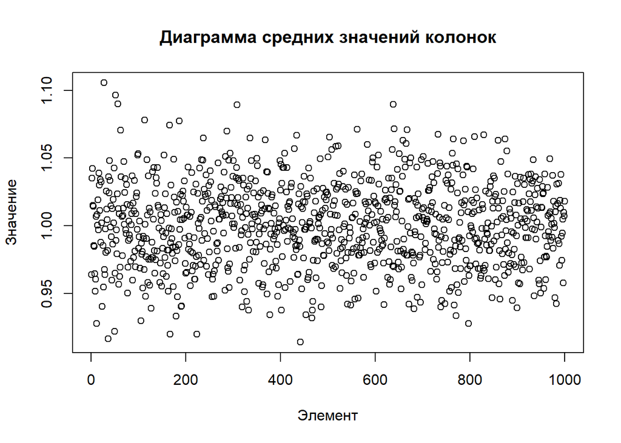

```r
mean_huge.exp.1.mat.all<-apply(huge.exp.1.mat,2,mean)
plot(mean_huge.exp.1.mat.all,xlab="Элемент",ylab="Значение",main = "Диаграмма средних значений колонок")
```

**Краткий вывод по диаграмме:** Данная диаграмма имеет такой вид, потому что она отражает средние значения векторов экспоненциального распределения. Соответственно получилась усредненная выборка экспоненциального распределения и большинство значений этой выборки лежат около среднего значения всего вектора значений.

- Рассчитайте квадрат каждого значения из *huge.exp.1* и найдите среднее и стандартное отклонение полученного вектора квадратов.

```r
square_huge.exp.1<-huge.exp.1^2
mean_square_huge.exp.1<-mean(square_huge.exp.1)
sd_square_huge.exp.1<-sd(square_huge.exp.1)
mean_square_huge.exp.1
```

```
## [1] 2.004454
```

```r
sd_square_huge.exp.1
```

```
## [1] 4.493421
```

Объясните отличие от соответствующих показателей вектора *huge.exp.1*. Вам может помочь формула, по которой R рассчитывает стандартное отклонение: `sqrt(sum((x-mean(x))^2)/(n-1))`

**Краткий вывод:**Отличие значений объясняется тем, что при получении среднего значения и стандартного отклонения у вектора, каждое значение которого возведенно в квадрат, все значения увеличиваются. Поэтому разброс значений от среднего увеличивается, соответственно и среднее значение увеличивается, а при получении стандартного отклонения с помощью ф-ии *sd()*, которая расщитывает значение с помощью формулы описанной выше, разность квадратов будет значительно больше, чем простая разница значений, поэтому и стандартное отклонение вектора квадратов значений больше обычного вектора.